# pr01

### 목차

- <Step1.> : 문제정의 및 가설설정
  - [문제정의]
  - [가설설정]
- <Step2.> : 데이터 수집
  - [데이터 불러오기]
  - [데이터 결합]
- <Step3.> : 데이터 전처리
  - [데이터 결측값 제거]
  - [데이터 구조 변경]
- <Step4.> : 데이터 모델링 및 시각화
  - [요인분석 1 : 지역구]
    - [1.1 유종 간 상관관계 _ (Pairplot Chart)]
    - [1.2 지역구별 유가 _ (Boxplot)]
    - [1.3 지역구별 유가 _ (Barplot)]
    - [1.4 지역구별 월별 유가 _ (Heatmap)]
  - [요인분석 2 : 인건비-셀프여부]
    - [2.1 인건비와 유가의 상관관계 _ (Violinplot)]
    - [2.2 지역구별 인건비와 유가의 상관관계 _ (Violinplot)]
  - [요인분석 3 : 대리점 공급가]
    - [3.1 지역별 대리점의 수 _ (Wordcloud) ]
    - [3.2 지역구별 대리점의 수와 유가 _ (Plot)]

# <Step1.> : 문제정의 및 가설설정

## [문제정의]

```
유가에 영향을 끼치는 요인들이 무엇인지 알아보고자 한다.
```

## [가설설정]

```
유가에 영향을 미치는 요인을 3가지로 설정하고 이 3가지요인이 각각 정말 유가에 영향을 미치는지 확인한다.

요인 1) 지역구
요인 2) 인건비 (셀프여부)
요인 3) 대리점 공급가
```

### [참고자료 ]

전략 : [같은 지역인데 주유소마다 기름값이 다른 이유는 무엇일까?](https://m.post.naver.com/viewer/postView.nhn?volumeNo=16980657&memberNo=40864363)  
시각화 : [데이터 사이언스 스쿨](https://datascienceschool.net/01%20python/05.04%20시본을%20사용한%20데이터%20분포%20시각화.html) [Seaborn gallery](https://seaborn.pydata.org/examples/index.html)

# <Step2.> : 데이터 수집

```python
import pandas as pd
import numpy as np
import seaborn as sns
import matplotlib.pyplot as plt
```

```python
import platform

from matplotlib import font_manager, rc

plt.rcParams['axes.unicode_minus'] = False

if platform.system() == 'Darwin':
    rc('font', family='AppleGothic')
elif platform.system() == 'Windows':
    path = "c:/Windows/Fonts/malgun.ttf"
    font_name = font_manager.FontProperties(fname=path).get_name()
    rc('font', family=font_name)
else:
    print('Unknown system... sorry~~~~')
```

## [데이터 불러오기]

```python
# 상반기 주유소 판매 데이터 불러오기
first = pd.read_csv('../data/2020년 상반기 주유소 판매가격.csv', encoding='cp949')
first
```

|  | 번호 | 지역 | 상호 | 주소 | 기간 | 상표 | 셀프여부 | 고급휘발유 | 휘발유 | 경유 | 실내등유 |
| --- | --- | --- | --- | --- | --- | --- | --- | --- | --- | --- | --- |
| 0 | 기준 : 월간(202001~202006) | NaN | NaN | NaN | NaN | NaN | NaN | NaN | NaN | NaN | NaN |
| 1 | A0006039 | 서울 강남구 | (유)동하석유 힐탑셀프주유소 | 서울 강남구 논현로 640 | 2020년 01월 | SK에너지 | 셀프 | 1802.00 | 1657.00 | 1495.00 | 0.0 |
| 2 | A0006039 | 서울 강남구 | (유)동하석유 힐탑셀프주유소 | 서울 강남구 논현로 640 | 2020년 02월 | SK에너지 | 셀프 | 1795.38 | 1637.97 | 1483.97 | 0.0 |
| 3 | A0006039 | 서울 강남구 | (유)동하석유 힐탑셀프주유소 | 서울 강남구 논현로 640 | 2020년 03월 | SK에너지 | 셀프 | 1741.26 | 1570.61 | 1431.13 | 0.0 |
| 4 | A0006039 | 서울 강남구 | (유)동하석유 힐탑셀프주유소 | 서울 강남구 논현로 640 | 2020년 04월 | SK에너지 | 셀프 | 1617.00 | 1425.33 | 1290.00 | 0.0 |
| ... | ... | ... | ... | ... | ... | ... | ... | ... | ... | ... | ... |
| 2990 | A0009197 | 서울 중랑구 | 현대오일뱅크㈜직영 중랑교셀프주유소 | 서울 중랑구 망우로 229 (중화동) | 2020년 02월 | SK에너지 | 셀프 | 1872.93 | 1542.14 | 1365.55 | 0.0 |
| 2991 | A0009197 | 서울 중랑구 | 현대오일뱅크㈜직영 중랑교셀프주유소 | 서울 중랑구 망우로 229 (중화동) | 2020년 03월 | SK에너지 | 셀프 | 1798.10 | 1479.32 | 1278.87 | 0.0 |
| 2992 | A0009197 | 서울 중랑구 | 현대오일뱅크㈜직영 중랑교셀프주유소 | 서울 중랑구 망우로 229 (중화동) | 2020년 04월 | SK에너지 | 셀프 | 1652.93 | 1322.80 | 1128.67 | 0.0 |
| 2993 | A0009197 | 서울 중랑구 | 현대오일뱅크㈜직영 중랑교셀프주유소 | 서울 중랑구 망우로 229 (중화동) | 2020년 05월 | SK에너지 | 셀프 | 1593.19 | 1252.55 | 1058.48 | 0.0 |
| 2994 | A0009197 | 서울 중랑구 | 현대오일뱅크㈜직영 중랑교셀프주유소 | 서울 중랑구 망우로 229 (중화동) | 2020년 06월 | 현대오일뱅크 | 셀프 | 1618.07 | 1328.73 | 1137.67 | 0.0 |

2995 rows × 11 columns

```python
second = pd.read_csv('../data/2020년 하반기 주유소 판매가격.csv', encoding='cp949')
second
```

|  | 번호 | 지역 | 상호 | 주소 | 기간 | 상표 | 셀프여부 | 고급휘발유 | 휘발유 | 경유 | 실내등유 |
| --- | --- | --- | --- | --- | --- | --- | --- | --- | --- | --- | --- |
| 0 | 기준 : 월간(202007~202012) | NaN | NaN | NaN | NaN | NaN | NaN | NaN | NaN | NaN | NaN |
| 1 | A0006039 | 서울 강남구 | (유)동하석유 힐탑셀프주유소 | 서울 강남구 논현로 640 | 2020년 07월 | SK에너지 | 셀프 | 1635.0 | 1435.00 | 1265.00 | 0.0 |
| 2 | A0006039 | 서울 강남구 | (유)동하석유 힐탑셀프주유소 | 서울 강남구 논현로 640 | 2020년 08월 | SK에너지 | 셀프 | 1635.0 | 1435.00 | 1265.00 | 0.0 |
| 3 | A0006039 | 서울 강남구 | (유)동하석유 힐탑셀프주유소 | 서울 강남구 논현로 640 | 2020년 09월 | SK에너지 | 셀프 | 1635.0 | 1435.00 | 1265.00 | 0.0 |
| 4 | A0006039 | 서울 강남구 | (유)동하석유 힐탑셀프주유소 | 서울 강남구 논현로 640 | 2020년 10월 | SK에너지 | 셀프 | 1635.0 | 1435.00 | 1265.00 | 0.0 |
| ... | ... | ... | ... | ... | ... | ... | ... | ... | ... | ... | ... |
| 2946 | A0009197 | 서울 중랑구 | 현대오일뱅크㈜직영 중랑교셀프주유소 | 서울 중랑구 망우로 229 (중화동) | 2020년 08월 | 현대오일뱅크 | 셀프 | 1598.0 | 1402.65 | 1211.10 | 0.0 |
| 2947 | A0009197 | 서울 중랑구 | 현대오일뱅크㈜직영 중랑교셀프주유소 | 서울 중랑구 망우로 229 (중화동) | 2020년 09월 | 현대오일뱅크 | 셀프 | 1598.0 | 1393.00 | 1203.00 | 0.0 |
| 2948 | A0009197 | 서울 중랑구 | 현대오일뱅크㈜직영 중랑교셀프주유소 | 서울 중랑구 망우로 229 (중화동) | 2020년 10월 | 현대오일뱅크 | 셀프 | 1598.0 | 1338.42 | 1148.42 | 0.0 |
| 2949 | A0009197 | 서울 중랑구 | 현대오일뱅크㈜직영 중랑교셀프주유소 | 서울 중랑구 망우로 229 (중화동) | 2020년 11월 | 현대오일뱅크 | 셀프 | 1598.0 | 1292.00 | 1092.37 | 0.0 |
| 2950 | A0009197 | 서울 중랑구 | 현대오일뱅크㈜직영 중랑교셀프주유소 | 서울 중랑구 망우로 229 (중화동) | 2020년 12월 | 현대오일뱅크 | 셀프 | 1598.0 | 1367.58 | 1167.58 | 0.0 |

2951 rows × 11 columns

## [데이터 결합]

```python
# 상반기와 하반기 데이터를 상하로 결합

df = pd.concat([first, second])
df
```

|  | 번호 | 지역 | 상호 | 주소 | 기간 | 상표 | 셀프여부 | 고급휘발유 | 휘발유 | 경유 | 실내등유 |
| --- | --- | --- | --- | --- | --- | --- | --- | --- | --- | --- | --- |
| 0 | 기준 : 월간(202001~202006) | NaN | NaN | NaN | NaN | NaN | NaN | NaN | NaN | NaN | NaN |
| 1 | A0006039 | 서울 강남구 | (유)동하석유 힐탑셀프주유소 | 서울 강남구 논현로 640 | 2020년 01월 | SK에너지 | 셀프 | 1802.00 | 1657.00 | 1495.00 | 0.0 |
| 2 | A0006039 | 서울 강남구 | (유)동하석유 힐탑셀프주유소 | 서울 강남구 논현로 640 | 2020년 02월 | SK에너지 | 셀프 | 1795.38 | 1637.97 | 1483.97 | 0.0 |
| 3 | A0006039 | 서울 강남구 | (유)동하석유 힐탑셀프주유소 | 서울 강남구 논현로 640 | 2020년 03월 | SK에너지 | 셀프 | 1741.26 | 1570.61 | 1431.13 | 0.0 |
| 4 | A0006039 | 서울 강남구 | (유)동하석유 힐탑셀프주유소 | 서울 강남구 논현로 640 | 2020년 04월 | SK에너지 | 셀프 | 1617.00 | 1425.33 | 1290.00 | 0.0 |
| ... | ... | ... | ... | ... | ... | ... | ... | ... | ... | ... | ... |
| 2946 | A0009197 | 서울 중랑구 | 현대오일뱅크㈜직영 중랑교셀프주유소 | 서울 중랑구 망우로 229 (중화동) | 2020년 08월 | 현대오일뱅크 | 셀프 | 1598.00 | 1402.65 | 1211.10 | 0.0 |
| 2947 | A0009197 | 서울 중랑구 | 현대오일뱅크㈜직영 중랑교셀프주유소 | 서울 중랑구 망우로 229 (중화동) | 2020년 09월 | 현대오일뱅크 | 셀프 | 1598.00 | 1393.00 | 1203.00 | 0.0 |
| 2948 | A0009197 | 서울 중랑구 | 현대오일뱅크㈜직영 중랑교셀프주유소 | 서울 중랑구 망우로 229 (중화동) | 2020년 10월 | 현대오일뱅크 | 셀프 | 1598.00 | 1338.42 | 1148.42 | 0.0 |
| 2949 | A0009197 | 서울 중랑구 | 현대오일뱅크㈜직영 중랑교셀프주유소 | 서울 중랑구 망우로 229 (중화동) | 2020년 11월 | 현대오일뱅크 | 셀프 | 1598.00 | 1292.00 | 1092.37 | 0.0 |
| 2950 | A0009197 | 서울 중랑구 | 현대오일뱅크㈜직영 중랑교셀프주유소 | 서울 중랑구 망우로 229 (중화동) | 2020년 12월 | 현대오일뱅크 | 셀프 | 1598.00 | 1367.58 | 1167.58 | 0.0 |

5946 rows × 11 columns

```python
# 지역 컬럼의 값을 이용하여 시와 구를 분리

df['시'] = df['지역'].str[:2]
df['구'] = df['지역'].str[3:]
df.head()
```

|  | 번호 | 지역 | 상호 | 주소 | 기간 | 상표 | 셀프여부 | 고급휘발유 | 휘발유 | 경유 | 실내등유 | 시 | 구 |
| --- | --- | --- | --- | --- | --- | --- | --- | --- | --- | --- | --- | --- | --- |
| 0 | 기준 : 월간(202001~202006) | NaN | NaN | NaN | NaN | NaN | NaN | NaN | NaN | NaN | NaN | NaN | NaN |
| 1 | A0006039 | 서울 강남구 | (유)동하석유 힐탑셀프주유소 | 서울 강남구 논현로 640 | 2020년 01월 | SK에너지 | 셀프 | 1802.00 | 1657.00 | 1495.00 | 0.0 | 서울 | 강남구 |
| 2 | A0006039 | 서울 강남구 | (유)동하석유 힐탑셀프주유소 | 서울 강남구 논현로 640 | 2020년 02월 | SK에너지 | 셀프 | 1795.38 | 1637.97 | 1483.97 | 0.0 | 서울 | 강남구 |
| 3 | A0006039 | 서울 강남구 | (유)동하석유 힐탑셀프주유소 | 서울 강남구 논현로 640 | 2020년 03월 | SK에너지 | 셀프 | 1741.26 | 1570.61 | 1431.13 | 0.0 | 서울 | 강남구 |
| 4 | A0006039 | 서울 강남구 | (유)동하석유 힐탑셀프주유소 | 서울 강남구 논현로 640 | 2020년 04월 | SK에너지 | 셀프 | 1617.00 | 1425.33 | 1290.00 | 0.0 | 서울 | 강남구 |

# <Step3.> : 데이터 전처리

## [결측값 제거]

```python
df.dropna(inplace=True)
df
```

|  | 번호 | 지역 | 상호 | 주소 | 기간 | 상표 | 셀프여부 | 고급휘발유 | 휘발유 | 경유 | 실내등유 | 시 | 구 |
| --- | --- | --- | --- | --- | --- | --- | --- | --- | --- | --- | --- | --- | --- |
| 1 | A0006039 | 서울 강남구 | (유)동하석유 힐탑셀프주유소 | 서울 강남구 논현로 640 | 2020년 01월 | SK에너지 | 셀프 | 1802.00 | 1657.00 | 1495.00 | 0.0 | 서울 | 강남구 |
| 2 | A0006039 | 서울 강남구 | (유)동하석유 힐탑셀프주유소 | 서울 강남구 논현로 640 | 2020년 02월 | SK에너지 | 셀프 | 1795.38 | 1637.97 | 1483.97 | 0.0 | 서울 | 강남구 |
| 3 | A0006039 | 서울 강남구 | (유)동하석유 힐탑셀프주유소 | 서울 강남구 논현로 640 | 2020년 03월 | SK에너지 | 셀프 | 1741.26 | 1570.61 | 1431.13 | 0.0 | 서울 | 강남구 |
| 4 | A0006039 | 서울 강남구 | (유)동하석유 힐탑셀프주유소 | 서울 강남구 논현로 640 | 2020년 04월 | SK에너지 | 셀프 | 1617.00 | 1425.33 | 1290.00 | 0.0 | 서울 | 강남구 |
| 5 | A0006039 | 서울 강남구 | (유)동하석유 힐탑셀프주유소 | 서울 강남구 논현로 640 | 2020년 05월 | SK에너지 | 셀프 | 1565.00 | 1350.81 | 1197.74 | 0.0 | 서울 | 강남구 |
| ... | ... | ... | ... | ... | ... | ... | ... | ... | ... | ... | ... | ... | ... |
| 2946 | A0009197 | 서울 중랑구 | 현대오일뱅크㈜직영 중랑교셀프주유소 | 서울 중랑구 망우로 229 (중화동) | 2020년 08월 | 현대오일뱅크 | 셀프 | 1598.00 | 1402.65 | 1211.10 | 0.0 | 서울 | 중랑구 |
| 2947 | A0009197 | 서울 중랑구 | 현대오일뱅크㈜직영 중랑교셀프주유소 | 서울 중랑구 망우로 229 (중화동) | 2020년 09월 | 현대오일뱅크 | 셀프 | 1598.00 | 1393.00 | 1203.00 | 0.0 | 서울 | 중랑구 |
| 2948 | A0009197 | 서울 중랑구 | 현대오일뱅크㈜직영 중랑교셀프주유소 | 서울 중랑구 망우로 229 (중화동) | 2020년 10월 | 현대오일뱅크 | 셀프 | 1598.00 | 1338.42 | 1148.42 | 0.0 | 서울 | 중랑구 |
| 2949 | A0009197 | 서울 중랑구 | 현대오일뱅크㈜직영 중랑교셀프주유소 | 서울 중랑구 망우로 229 (중화동) | 2020년 11월 | 현대오일뱅크 | 셀프 | 1598.00 | 1292.00 | 1092.37 | 0.0 | 서울 | 중랑구 |
| 2950 | A0009197 | 서울 중랑구 | 현대오일뱅크㈜직영 중랑교셀프주유소 | 서울 중랑구 망우로 229 (중화동) | 2020년 12월 | 현대오일뱅크 | 셀프 | 1598.00 | 1367.58 | 1167.58 | 0.0 | 서울 | 중랑구 |

5944 rows × 13 columns

## [데이터 구조 변경]

```python
# 시 컬럼의 서울을 서울특별시로 변환

df['시'] += '특별시'
df.head()
```

|  | 번호 | 지역 | 상호 | 주소 | 기간 | 상표 | 셀프여부 | 고급휘발유 | 휘발유 | 경유 | 실내등유 | 시 | 구 |
| --- | --- | --- | --- | --- | --- | --- | --- | --- | --- | --- | --- | --- | --- |
| 1 | A0006039 | 서울 강남구 | (유)동하석유 힐탑셀프주유소 | 서울 강남구 논현로 640 | 2020년 01월 | SK에너지 | 셀프 | 1802.00 | 1657.00 | 1495.00 | 0.0 | 서울특별시 | 강남구 |
| 2 | A0006039 | 서울 강남구 | (유)동하석유 힐탑셀프주유소 | 서울 강남구 논현로 640 | 2020년 02월 | SK에너지 | 셀프 | 1795.38 | 1637.97 | 1483.97 | 0.0 | 서울특별시 | 강남구 |
| 3 | A0006039 | 서울 강남구 | (유)동하석유 힐탑셀프주유소 | 서울 강남구 논현로 640 | 2020년 03월 | SK에너지 | 셀프 | 1741.26 | 1570.61 | 1431.13 | 0.0 | 서울특별시 | 강남구 |
| 4 | A0006039 | 서울 강남구 | (유)동하석유 힐탑셀프주유소 | 서울 강남구 논현로 640 | 2020년 04월 | SK에너지 | 셀프 | 1617.00 | 1425.33 | 1290.00 | 0.0 | 서울특별시 | 강남구 |
| 5 | A0006039 | 서울 강남구 | (유)동하석유 힐탑셀프주유소 | 서울 강남구 논현로 640 | 2020년 05월 | SK에너지 | 셀프 | 1565.00 | 1350.81 | 1197.74 | 0.0 | 서울특별시 | 강남구 |

# <Step4.> : 데이터 모델링 및 시각화

## [요인분석1 : 지역구]

### 1.1 유종 간 상관관계 _ (Pairplot Chart)

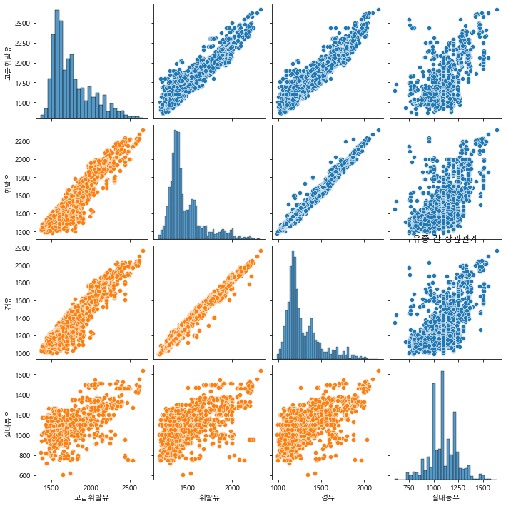

```python
df_nonull= df.replace(0, np.NaN)
df_nonull

import matplotlib.pyplot as plt
import matplotlib.font_manager as fm

fm.get_fontconfig_fonts()
font_location = 'C:\Windows\Fonts\malgun.ttf'
font_name = fm.FontProperties(fname=font_location).get_name()
plt.rc('font', family=font_name)

graph = sns.pairplot(df_nonull)
graph.map_lower(sns.scatterplot)
graph.map_upper(sns.regplot, scatter=False, truncate=False, ci=False)
plt.title("유종 간 상관관계")
plt.show()
```

#### 분석결과

```
지역구 별 유가를 비교하기 전에 유가별 상관관계를 파악하여 가장 대표적인 유종이 무엇인지 알아보았다.

> 분석결과 : 모든 유종은 양의 상관관계를 가지고있으며 그 중에서도 휘발유와 경유의 상관관계가 제일 높다.
  따라서, 편의상 휘발유를 대표적 유종으로 선정하였다.
```

### 1.2 지역구별 유가 _ (Boxplot)

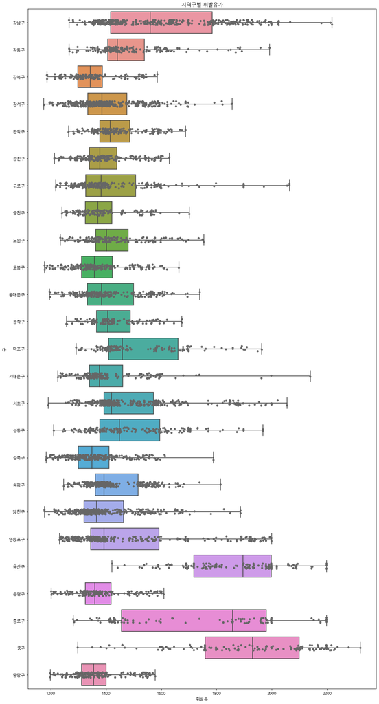

```python
plt.figure(figsize=(15, 30))
plt.title("지역구별 휘발유가")
sns.boxplot(x="휘발유", y="구", data=df, whis=np.inf)
sns.stripplot(x="휘발유", y="구", data=df, jitter=True, color="0.4")
plt.show()
```

#### 분석결과

```
대표 유종인 휘발유의 지역구별 가격을 알아보았다.

> 분석결과 : Boxplot으로 알 수 있는 것은 중앙값, 산포도, 최대값, 최소값, 이상치 등이 있다.
위 그래프를 해석하면, 휘발유의 평균가격이 가장 높은 지역구는 중구, 용산구, 종로구 순이고 가장 낮은 지역구는 강북구,성북구, 중랑구
임을 알 수 있다.

특히, 중구의 그래프를 보면 2,3,4분위수 범위의 간격이 비교적 일정한 것으로보아 중구의 높은 휘발유 평균가격은 이상치에 의해 좌우된 결과가 아님을 알 수 있다.

따라서, 해당 그래프는 유의미하다.
```

### 1.3 지역구별 유가 _ (Barplot)

```python
df_a = df.replace(0, np.NaN) # 0을 제외하고 평균을 내기 위해 nan처리
df_a = df_a.groupby('구')[['고급휘발유', '휘발유', '경유', '실내등유']].mean() # df의 mean()은 nan 제외한 평균을 내줌
df_a
```

| 구 | 고급휘발유 | 휘발유 | 경유 | 실내등유 |
| --- | --- | --- | --- | --- |
| 강남구 | 1820.577020 | 1601.450148 | 1426.829409 | 1250.738244 |
| 강동구 | 1742.760476 | 1483.317188 | 1297.847500 | 1082.447983 |
| 강북구 | 1740.838125 | 1358.062500 | 1168.330962 | 942.135278 |
| 강서구 | 1616.750072 | 1407.981343 | 1218.795721 | 1068.254754 |
| 관악구 | 1678.794375 | 1440.764404 | 1266.050363 | 1087.529294 |
| 광진구 | 1633.337292 | 1397.081373 | 1202.645196 | 1065.067746 |
| 구로구 | 1588.155789 | 1429.092710 | 1226.033435 | 1070.564000 |
| 금천구 | 1533.020625 | 1390.482484 | 1196.913248 | 1065.275529 |
| 노원구 | 1661.301000 | 1434.355371 | 1246.633600 | 1066.436341 |
| 도봉구 | 1669.422292 | 1378.404167 | 1190.656389 | 993.692963 |
| 동대문구 | 1616.753056 | 1408.674144 | 1215.942824 | 1088.621518 |
| 동작구 | 1600.552453 | 1430.096083 | 1264.556583 | 1060.882778 |
| 마포구 | 1835.779714 | 1533.331408 | 1356.522676 | 1161.473958 |
| 서대문구 | 1708.995488 | 1413.302099 | 1223.311547 | 1140.450896 |
| 서초구 | 1712.043105 | 1490.589930 | 1324.340634 | 1155.363154 |
| 성동구 | 1758.545816 | 1492.690099 | 1307.588218 | 1165.003548 |
| 성북구 | 1666.202018 | 1362.384425 | 1173.994390 | 1034.432033 |
| 송파구 | 1595.915313 | 1423.959394 | 1242.611439 | 1125.365122 |
| 양천구 | 1637.812301 | 1401.761962 | 1209.962310 | 1083.694105 |
| 영등포구 | 1804.245648 | 1497.842619 | 1313.364603 | 1122.859420 |
| 용산구 | 2133.165179 | 1858.926071 | 1709.826726 | 1154.484000 |
| 은평구 | 1560.113553 | 1382.617371 | 1192.846031 | 966.631096 |
| 종로구 | 2036.235000 | 1746.083853 | 1571.764495 | 1146.844706 |
| 중구 | 2194.344646 | 1904.910216 | 1718.084029 | 1197.343226 |
| 중랑구 | 1618.713793 | 1370.667396 | 1180.817396 | 1011.434426 |

```python
df_a.reset_index(inplace=True)
df_a
```

|  | 구 | 고급휘발유 | 휘발유 | 경유 | 실내등유 |
| --- | --- | --- | --- | --- | --- |
| 0 | 강남구 | 1820.577020 | 1601.450148 | 1426.829409 | 1250.738244 |
| 1 | 강동구 | 1742.760476 | 1483.317188 | 1297.847500 | 1082.447983 |
| 2 | 강북구 | 1740.838125 | 1358.062500 | 1168.330962 | 942.135278 |
| 3 | 강서구 | 1616.750072 | 1407.981343 | 1218.795721 | 1068.254754 |
| 4 | 관악구 | 1678.794375 | 1440.764404 | 1266.050363 | 1087.529294 |
| 5 | 광진구 | 1633.337292 | 1397.081373 | 1202.645196 | 1065.067746 |
| 6 | 구로구 | 1588.155789 | 1429.092710 | 1226.033435 | 1070.564000 |
| 7 | 금천구 | 1533.020625 | 1390.482484 | 1196.913248 | 1065.275529 |
| 8 | 노원구 | 1661.301000 | 1434.355371 | 1246.633600 | 1066.436341 |
| 9 | 도봉구 | 1669.422292 | 1378.404167 | 1190.656389 | 993.692963 |
| 10 | 동대문구 | 1616.753056 | 1408.674144 | 1215.942824 | 1088.621518 |
| 11 | 동작구 | 1600.552453 | 1430.096083 | 1264.556583 | 1060.882778 |
| 12 | 마포구 | 1835.779714 | 1533.331408 | 1356.522676 | 1161.473958 |
| 13 | 서대문구 | 1708.995488 | 1413.302099 | 1223.311547 | 1140.450896 |
| 14 | 서초구 | 1712.043105 | 1490.589930 | 1324.340634 | 1155.363154 |
| 15 | 성동구 | 1758.545816 | 1492.690099 | 1307.588218 | 1165.003548 |
| 16 | 성북구 | 1666.202018 | 1362.384425 | 1173.994390 | 1034.432033 |
| 17 | 송파구 | 1595.915313 | 1423.959394 | 1242.611439 | 1125.365122 |
| 18 | 양천구 | 1637.812301 | 1401.761962 | 1209.962310 | 1083.694105 |
| 19 | 영등포구 | 1804.245648 | 1497.842619 | 1313.364603 | 1122.859420 |
| 20 | 용산구 | 2133.165179 | 1858.926071 | 1709.826726 | 1154.484000 |
| 21 | 은평구 | 1560.113553 | 1382.617371 | 1192.846031 | 966.631096 |
| 22 | 종로구 | 2036.235000 | 1746.083853 | 1571.764495 | 1146.844706 |
| 23 | 중구 | 2194.344646 | 1904.910216 | 1718.084029 | 1197.343226 |
| 24 | 중랑구 | 1618.713793 | 1370.667396 | 1180.817396 | 1011.434426 |

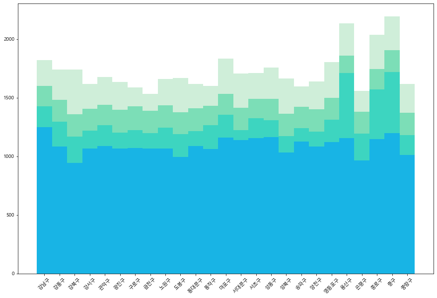

```python
plt.figure(figsize=(15, 10))
plt.xticks(rotation=45)

plt.bar(df_a['구'], df_a['고급휘발유'], alpha = 0.3, width=1, color='#62c983')
plt.bar(df_a['구'], df_a['휘발유'], alpha = 0.4, width=1, color="#00c786")
plt.bar(df_a['구'], df_a['경유'], alpha = 0.5, width=1, color="#00cec9")
plt.bar(df_a['구'], df_a['실내등유'], alpha = 0.6, width=1, color="#009fff")

plt.show()
```

#### 분석결과

```
지역별 전체 유가 평균을 살펴보았다.

> 분석결과 : Boxplot으로 봤을 때와 같이 평균가격이 가장 높은 지역구는 중구, 용산구, 종로구 순이고 가장 낮은 지역구는 강북구,성북구, 중랑구임을 알 수 있다.또한 지역구별로 유종간에 상관관계가 있음도 확인할 수 있었다.
```

### 1.4 지역구별 월별 유가 _ (Heatmap)

```python
df1=df.replace(0,np.NaN)
df1=df1.groupby(['구','기간'])[['고급휘발유','휘발유','경유','실내등유']].mean()
df1
```

| 구 | 기간 | 고급휘발유 | 휘발유 | 경유 | 실내등유 |
| --- | --- | --- | --- | --- | --- |
| 강남구 | 2020년 01월 | 1983.367059 | 1771.252750 | 1620.019000 | 1332.228462 |
|  | 2020년 02월 | 1968.100294 | 1754.086750 | 1600.688750 | 1332.799167 |
|  | 2020년 03월 | 1928.760588 | 1703.356500 | 1545.263750 | 1313.131818 |
|  | 2020년 04월 | 1815.537941 | 1580.068250 | 1418.166250 | 1230.497692 |
|  | 2020년 05월 | 1740.169118 | 1504.057250 | 1335.514000 | 1161.004545 |
| ... | ... | ... | ... | ... | ... |
| 중랑구 | 2020년 08월 | 1570.570000 | 1364.416875 | 1165.096875 | 995.800000 |
|  | 2020년 09월 | 1564.000000 | 1349.686250 | 1151.018125 | 995.000000 |
|  | 2020년 10월 | 1560.130000 | 1326.126250 | 1126.568750 | 982.742000 |
|  | 2020년 11월 | 1555.600000 | 1306.229375 | 1107.904375 | 966.500000 |
|  | 2020년 12월 | 1575.270000 | 1371.651875 | 1171.588750 | 987.452000 |

300 rows × 4 columns

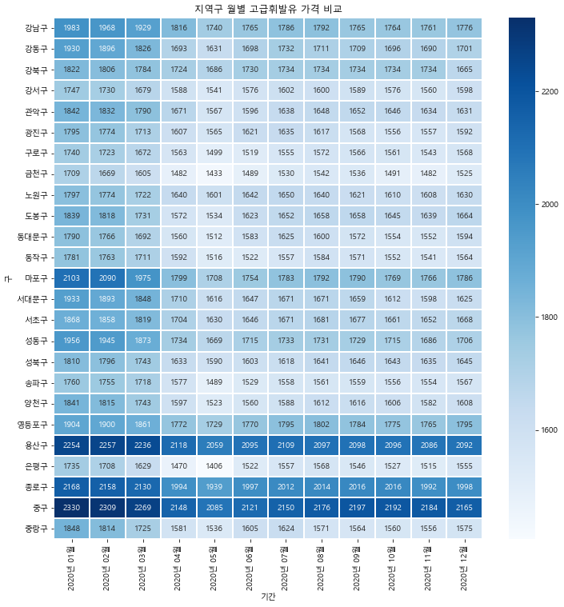

```python
df2=pd.pivot_table(df1,index="구",columns='기간', values="고급휘발유")
df3=pd.pivot_table(df1,index="구",columns='기간', values="휘발유")
df4=pd.pivot_table(df1,index="구",columns='기간', values="경유")
df5=pd.pivot_table(df1,index="구",columns='기간', values="실내등유")
plt.figure(figsize=(12, 12))
sns.heatmap(df2,annot=True,fmt=".0f",linewidths=1,cmap='Blues')
plt.title('지역구 월별 고급휘발유 가격 비교')
plt.show()
```

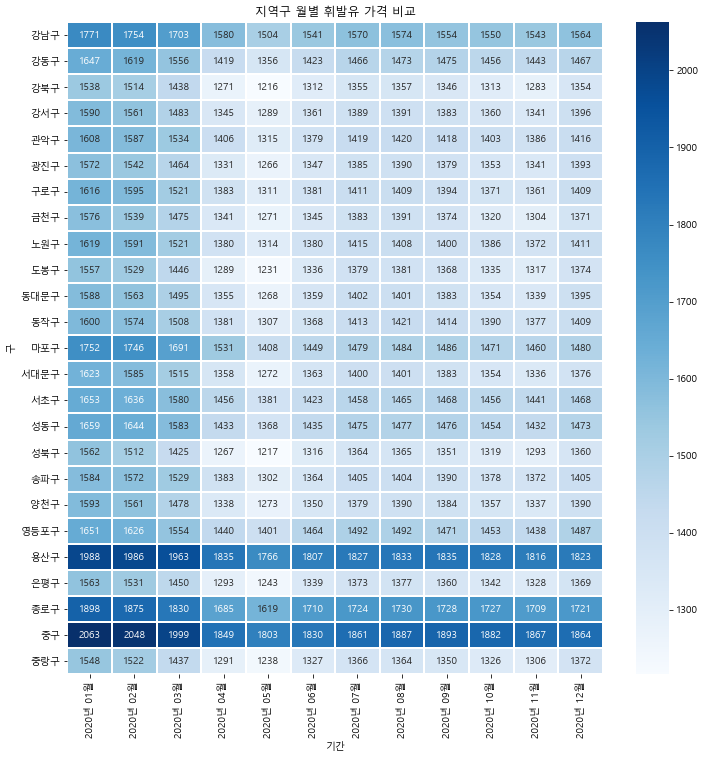

```python
plt.figure(figsize=(12, 12))
sns.heatmap(df3,annot=True,fmt=".0f",linewidths=1,cmap='Blues')
plt.title('지역구 월별 휘발유 가격 비교')
plt.show()
```

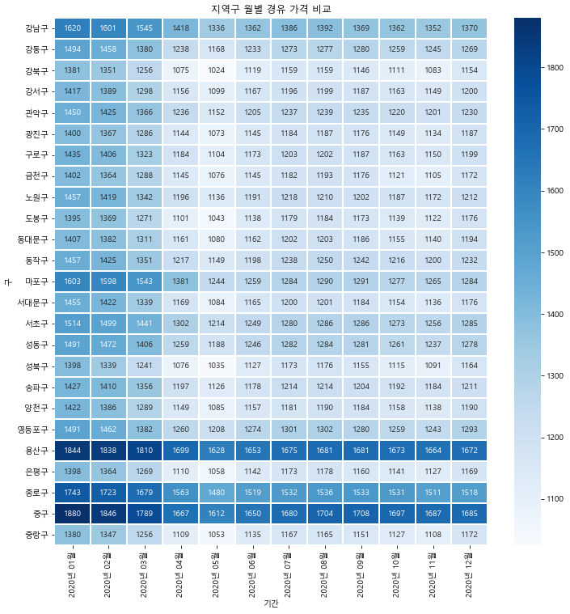

```python
plt.figure(figsize=(12, 12))
sns.heatmap(df4,annot=True,fmt=".0f",linewidths=1,cmap='Blues')
plt.title('지역구 월별 경유 가격 비교')
plt.show()
```

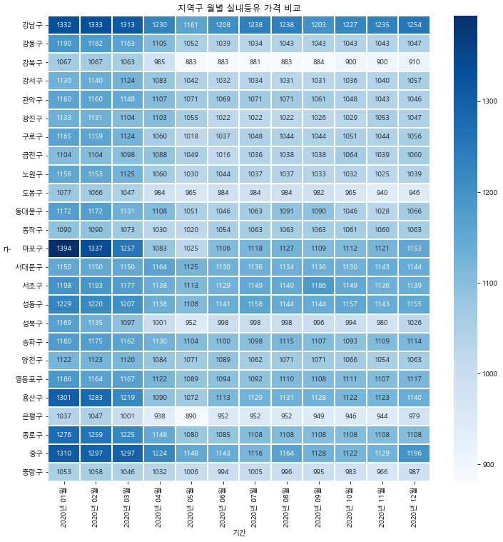

```python
plt.figure(figsize=(12, 12))
sns.heatmap(df5,annot=True,fmt=".0f",linewidths=1,cmap='Blues')
plt.title('지역구 월별 실내등유 가격 비교')
plt.show()
```

#### 분석결과

[output not shown]

## [요인분석2 : 인건비]

### 2.1 인건비와 유가의 상관관계 _ (Violinplot)

```python
# 한글처리
import matplotlib.pyplot as plt
import matplotlib.font_manager as fm

fm.get_fontconfig_fonts()
font_location = 'C:\Windows\Fonts\malgun.ttf'
font_name = fm.FontProperties(fname=font_location).get_name()
plt.rc('font', family=font_name)
```

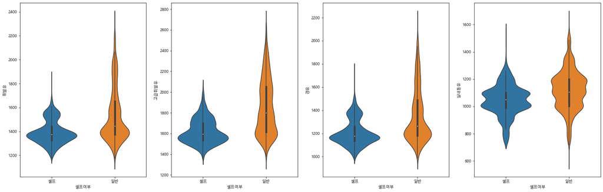

```python
df0 = df.replace(0, np.NaN)
fig, ax = plt.subplots(figsize=(26, 8), ncols=4)
sns.violinplot(data=df0,x='셀프여부', y='휘발유', ax=ax[0])
sns.violinplot(data=df0,x='셀프여부', y='고급휘발유',  ax=ax[1])
sns.violinplot(data=df0,x='셀프여부', y='경유',  ax=ax[2])
sns.violinplot(data=df0,x='셀프여부', y='실내등유', ax=ax[3])

plt.show()
```

#### 분석결과

```
  인건비가 유가에 미치는 영향을 알아보았다.

> 분석결과 : 대부분의 지역에서는 유종에 상관없이 셀프주유소의 가격이 일반 주유소의 가격보다 저렴하다는 것을 알 수 있다.
```

### 2.2 지역구별 인건비와 유가의 상관관계 _ (Violinplot)

[figure not shown]

```python
fig, ax = plt.subplots(figsize=(120, 8),ncols=4)
sns.violinplot(data=df, hue='셀프여부',x='구', y='휘발유', split=True, ax=ax[0])
sns.violinplot(data=df, hue='셀프여부',x='구', y='고급휘발유', split=True, ax=ax[1])
sns.violinplot(data=df, hue='셀프여부',x='구', y='경유', split=True, ax=ax[2])
sns.violinplot(data=df, hue='셀프여부',x='구', y='실내등유', split=True, ax=ax[3])
plt.show()
```

#### 분석결과

[output not shown]

## [요인분석3 : 대리점 공급가]

### 3.1 지역별 대리점의 수 _ (Wordcloud)

```python
# 서울시 전체 상호 중복
part = df
part.dropna(inplace=True)
seoul=part.drop_duplicates(['상호'], keep='first')
```

```python
#서울 상표 카운트
s_freq = seoul.groupby(['상표']).count()
s_count = s_freq.loc[:,['지역']]
s_count
```

| 상표 | 지역 |
| --- | --- |
| GS칼텍스 | 133 |
| S-OIL | 76 |
| SK에너지 | 190 |
| 알뜰(ex) | 1 |
| 알뜰주유소 | 11 |
| 자가상표 | 2 |
| 현대오일뱅크 | 80 |

```python
sdict0 = s_count['지역'].to_dict()
추가 = {"가장 많은":1, "주유소는":1, "어디일까??":1, "부자동네에는?":1, "어떤주유소가?":1,
         "gs???":1, "sk??":1, "S-OIL??":1, "서울에서":1, "강남구에서":1, "강북구에서":1,
      "강서구에서":1, "관악구에서":1, "광진구에서":1, "구로구에서":1, "금천구에서":1, "노원구에서":1,
      "도봉구에서":1, "동대문구에서":1, "동작구에서":1, "마포구에서":1, "서대문구에서":1, "서초구에서":1,
      "성동구에서":1, "성북구에서":1, "송파구에서":1, "양천구에서":1, "영등포구에서":1, "용산구에서":1,
      "은평구에서":1, "종로구에서":1, "중구에서":1, "중랑구에서":1, "이상한 곳도 있네":1, "알뜰이 뭐야":1,
         "당신은":1, "어떤주유소를 좋아하세요?":1, "Pick!!":1, "와 이거 리얼?":1, "진짜?":1, "아하":1,
         "생각보다 ":1, "주유소 종류가 없네":1, "현대주유소??":1, "셀프주유소도 많고":1, "자아상표도 있고":1,
         "과연":1, "어떤결과가":1}
sdict0.update(추가)
```

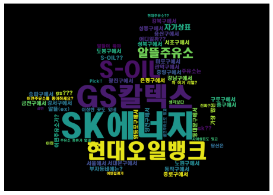

```python
from wordcloud import WordCloud
from PIL import Image
import numpy as np

imgmask = np.array(Image.open("img\seoul.png"))

keywords = sdict0

wc = WordCloud(font_path="C:\Windows\Fonts\HMKMRHD.ttf",
                         width=800,
                         height=600,
                         background_color='black',
                         mask = imgmask
                         )


cloud=wc.generate_from_frequencies(keywords)
plt.figure(figsize=(8, 8))
plt.imshow(cloud)
plt.axis("off")
plt.show()
```

#### 분석결과

```
 지역별 대리점의 수를 알아보았다.
```

### 3.2 지역구별 대리점의 수와 유가 _ (Plot)

```python
df_m = df.replace(0, np.NaN) # 0을 제외하고 평균을 내기 위해 nan처리
df_m = df_m.groupby('상표')[['휘발유']].mean() # df의 mean()은 nan 제외한 평균을 내줌
df_m
```

| 상표 | 휘발유 |
| --- | --- |
| GS칼텍스 | 1480.077478 |
| S-OIL | 1434.653561 |
| SK에너지 | 1517.494476 |
| 알뜰(ex) | 1330.236667 |
| 알뜰주유소 | 1355.216043 |
| 자가상표 | 1414.056800 |
| 현대오일뱅크 | 1427.582881 |

```python
# 추가됨
df_m.sort_values(by='휘발유').drop(['알뜰(ex)', '알뜰주유소', '자가상표'])
```

| 상표 | 휘발유 |
| --- | --- |
| 현대오일뱅크 | 1427.582881 |
| S-OIL | 1434.653561 |
| GS칼텍스 | 1480.077478 |
| SK에너지 | 1517.494476 |

```python
df_k = df.pivot_table('휘발유', index='구', columns='상표', aggfunc='count').dropna(thresh=20, axis=1)
df_k.fillna(0, inplace=True)
df_k
```

| 상표 구 | GS칼텍스 | S-OIL | SK에너지 | 현대오일뱅크 |
| --- | --- | --- | --- | --- |
| 강남구 | 143.0 | 71.0 | 186.0 | 74.0 |
| 강동구 | 60.0 | 24.0 | 63.0 | 45.0 |
| 강북구 | 36.0 | 24.0 | 53.0 | 43.0 |
| 강서구 | 84.0 | 72.0 | 142.0 | 68.0 |
| 관악구 | 45.0 | 24.0 | 60.0 | 48.0 |
| 광진구 | 60.0 | 36.0 | 46.0 | 50.0 |
| 구로구 | 48.0 | 72.0 | 53.0 | 77.0 |
| 금천구 | 34.0 | 36.0 | 41.0 | 31.0 |
| 노원구 | 72.0 | 36.0 | 48.0 | 19.0 |
| 도봉구 | 36.0 | 72.0 | 46.0 | 62.0 |
| 동대문구 | 68.0 | 33.0 | 86.0 | 76.0 |
| 동작구 | 36.0 | 12.0 | 22.0 | 50.0 |
| 마포구 | 12.0 | 34.0 | 70.0 | 26.0 |
| 서대문구 | 35.0 | 36.0 | 77.0 | 33.0 |
| 서초구 | 167.0 | 60.0 | 130.0 | 57.0 |
| 성동구 | 36.0 | 24.0 | 82.0 | 48.0 |
| 성북구 | 84.0 | 58.0 | 57.0 | 76.0 |
| 송파구 | 120.0 | 48.0 | 135.0 | 93.0 |
| 양천구 | 60.0 | 12.0 | 132.0 | 100.0 |
| 영등포구 | 119.0 | 31.0 | 140.0 | 76.0 |
| 용산구 | 48.0 | 0.0 | 87.0 | 33.0 |
| 은평구 | 72.0 | 24.0 | 53.0 | 32.0 |
| 종로구 | 24.0 | 24.0 | 42.0 | 19.0 |
| 중구 | 43.0 | 12.0 | 60.0 | 12.0 |
| 중랑구 | 60.0 | 60.0 | 53.0 | 19.0 |

```python
# df_k = (df_k['SK에너지'] + df_k['GS칼텍스']) / (df_k['S-OIL'] + df_k['현대오일뱅크'])
df_k = df_k['SK에너지'] / df_k['현대오일뱅크']
df_k
```

```
구
강남구     2.513514
강동구     1.400000
강북구     1.232558
강서구     2.088235
관악구     1.250000
광진구     0.920000
구로구     0.688312
금천구     1.322581
노원구     2.526316
도봉구     0.741935
동대문구    1.131579
동작구     0.440000
마포구     2.692308
서대문구    2.333333
서초구     2.280702
성동구     1.708333
성북구     0.750000
송파구     1.451613
양천구     1.320000
영등포구    1.842105
용산구     2.636364
은평구     1.656250
종로구     2.210526
중구      5.000000
중랑구     2.789474
dtype: float64
```

```python
df_k.sort_values()
```

```
구
동작구     0.440000
구로구     0.688312
도봉구     0.741935
성북구     0.750000
광진구     0.920000
동대문구    1.131579
강북구     1.232558
관악구     1.250000
양천구     1.320000
금천구     1.322581
강동구     1.400000
송파구     1.451613
은평구     1.656250
성동구     1.708333
영등포구    1.842105
강서구     2.088235
종로구     2.210526
서초구     2.280702
서대문구    2.333333
강남구     2.513514
노원구     2.526316
용산구     2.636364
마포구     2.692308
중랑구     2.789474
중구      5.000000
dtype: float64
```

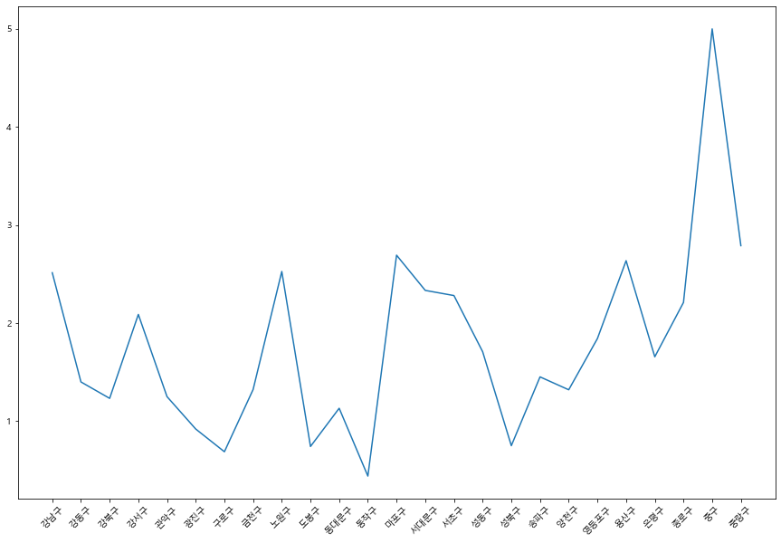

```python
plt.figure(figsize=(15, 10))
plt.xticks(rotation=45)

plt.plot(df_k)
```

```python
df_k = df_k * 200 + 1000
```

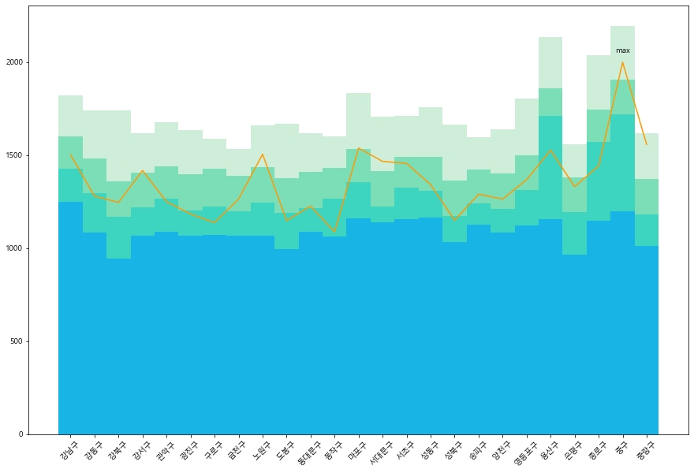

```python
plt.figure(figsize=(15, 10))
plt.xticks(rotation=45)
plt.text(22.7, 2050, f"max")

plt.bar(df_a['구'], df_a['고급휘발유'], alpha = 0.3, width=1, color='#62c983')
plt.bar(df_a['구'], df_a['휘발유'], alpha = 0.4, width=1, color="#00c786")
plt.bar(df_a['구'], df_a['경유'], alpha = 0.5, width=1, color="#00cec9")
plt.bar(df_a['구'], df_a['실내등유'], alpha = 0.6, width=1, color="#009fff")
plt.plot(df_k, color='#ff9900')

plt.show()
```

#### 분석결과

[output not shown]

### Feedback

- 데이터 전략 잘짰다.
- 데이터 수집 : 기업, 공공, 크롤링
- 데이터 전략은 전처리에 많은 영향을 끼친다.
- 강남구가 있는데 중구가 왜 비쌀까 같은 거? 아쉽
- 시각화 여러 그래프로 해서 좋았다.

### 아쉬운 점

- 우리는 주어진 데이터에 국한되어 분석하는 걸 당연하게 생각했다. 하지만 외부 데이터를 가지고 와서 사용한 팀을 보고, 갇힌 사고를 한 게 아닌가 생각했다.
- 다른 팀 작업방식 중 질문에 대한 답을 찾아낼 때까지 과정을 담아낸 게 좋았던 것 같다.
- 다른 팀들의 발표를 보고 좋았던 시각화 자료들

### 다른 팀 잘한 거

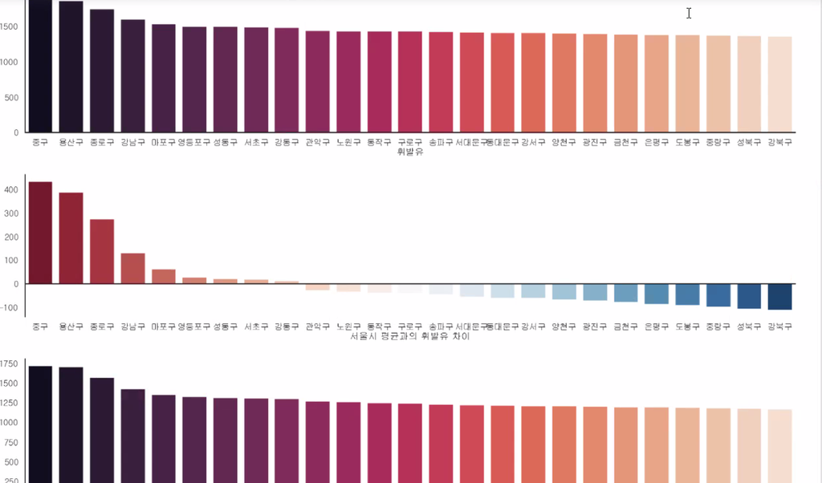

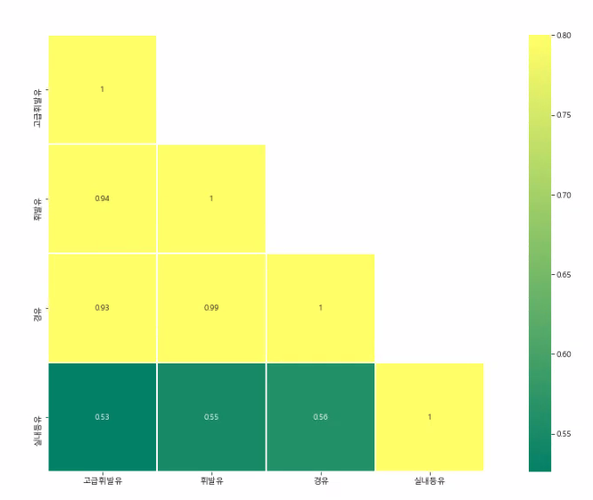